# Assignment 3: Multi-class classification

## Task 2: Run kfold validation to choose hyperparameters

We will use kfold validation to pick help us choose hyperparameters in the SVC method. We will focus on these two hyperparameters:

- gamma: Gamma determines the influence of individual training examples on the decision boundary. The gamma parameter defines how far the influence of a single training example reaches, with low values meaning 'far' and high values meaning 'close'.
- kernel: The kernel refers to the kernel function used by SVC. Kernel functions are used to map the input data points into a higher-dimensional space where the separation between the two classes becomes easier. This allows SVC to solve complex non-linear problems as well.

We will use a dictionary to store the hyperparameters we want to try - ours will have 7 entries, with different combinations of gamma and kernel.

Here we want to loop over the kfolds (just like we did in the in-class version), but we want to calculate the average "test" recall (accuracy) and precision over the folds.

You can get this by pulling the macro average recall out of the results_test dictionary.

Store these in a dictionary called "avg_recall_results". The key should be (gamma,kernel), and you can store it in the loop like this:

```
    avg_recall_results[(gamma,kernel)] = avg_recall_weighted_test
```

Do the same thing for precision!

This might be tricky so ask for help if you need it!

```python
#
# Get our estimator and predict
from sklearn.svm import LinearSVC
from sklearn.svm import SVC
from sklearn.linear_model import SGDClassifier
from sklearn.model_selection import StratifiedKFold
from sklearn.model_selection import KFold
from sklearn.metrics import precision_score, recall_score
import numpy as np

kfolds = 4
skf = StratifiedKFold(n_splits=kfolds)
#skf = KFold(n_splits=kfolds)
#
# Cresate some vars to keep track of everything
numSplits = 0.0
#

#
# Also keep track of the
hyper_parameters = [{'gamma':'auto','kernel':'linear'},
                            {'gamma':'auto','kernel':'sigmoid'},
                            {'gamma':'auto','kernel':'rbf'},
                            {'gamma':'scale','kernel':'linear'},
                            {'gamma':'scale','kernel':'poly'},
                            {'gamma':'scale','kernel':'sigmoid'},
                            {'gamma':'scale','kernel':'rbf'}
                   ]

#
# Store results in dictionary
avg_recall_results = {}
avg_precision_results = {}
#
# Loop over hyperparameters
for hyp in hyper_parameters:
    kernel = hyp['kernel']
    gamma = hyp['gamma']

    print()
    print('kernel,gamma:', kernel, gamma)

    recalls = []
    precisions = []

    for train_idx, test_idx in skf.split(X, y):
        X_train, X_test = X[train_idx], X[test_idx]
        y_train, y_test = y[train_idx], y[test_idx]

        model = SVC(gamma=gamma, kernel=kernel)
        model.fit(X_train, y_train)
        y_pred = model.predict(X_test)

        recalls.append(recall_score(y_test, y_pred, average="macro", zero_division=0))
        precisions.append(precision_score(y_test, y_pred, average="macro", zero_division=0))

    avg_recall_results[(gamma, kernel)] = np.mean(recalls)
    avg_precision_results[(gamma, kernel)] = np.mean(precisions)
```

```
kernel,gamma: linear auto

kernel,gamma: sigmoid auto

kernel,gamma: rbf auto

kernel,gamma: linear scale

kernel,gamma: poly scale

kernel,gamma: sigmoid scale

kernel,gamma: rbf scale
```

## Task 3: Make a Table summarizing hyperparametr results

Do this programmatically - looping over the dictionary of results you made above. The result table should look like this:

| gamma | kernel | Average Recall | Average Precision |
| --- | --- | --- | --- |
| auto | linear | xx | yy |
| auto | sigmoid | xx | yy |
| auto | rbf | xx | yy |
| scale | linear | xx | yy |
| scale | poly | xx | yy |
| scale | sigmoid | xx | yy |
| scale | rbf | xx | yy |

We do some of it for you.

```python
# your code here

table = [
    [ "gamma", "kernel", "Average Recall", "Average Precision"]
]
for (gamma,kernel) in avg_recall_results:
    table.append([gamma,kernel,avg_recall_results[(gamma,kernel)],avg_precision_results[(gamma,kernel)]])
#
# Now you print it out
# Print as a nice table
print(tabulate(table, headers="firstrow", tablefmt="fancy_grid"))
```

```
╒═════════╤══════════╤══════════════════╤═════════════════════╕
│ gamma   │ kernel   │   Average Recall │   Average Precision │
╞═════════╪══════════╪══════════════════╪═════════════════════╡
│ auto    │ linear   │         0.950955 │            0.952313 │
├─────────┼──────────┼──────────────────┼─────────────────────┤
│ auto    │ sigmoid  │         0.1      │            0.010162 │
├─────────┼──────────┼──────────────────┼─────────────────────┤
│ auto    │ rbf      │         0.436106 │            0.915326 │
├─────────┼──────────┼──────────────────┼─────────────────────┤
│ scale   │ linear   │         0.950955 │            0.952313 │
├─────────┼──────────┼──────────────────┼─────────────────────┤
│ scale   │ poly     │         0.971745 │            0.972293 │
├─────────┼──────────┼──────────────────┼─────────────────────┤
│ scale   │ sigmoid  │         0.891523 │            0.896858 │
├─────────┼──────────┼──────────────────┼─────────────────────┤
│ scale   │ rbf      │         0.965567 │            0.966645 │
╘═════════╧══════════╧══════════════════╧═════════════════════╛
```

## Task 4: Rerun using the best hyperparameters, get average per digit accuracy

After inspecting the above table, determine the best hyperparameter combination.

Using those hyperparemeters, we now want to determine how well a newly trained model will perform on unseen data. We will again use kfold validation to do this.

- Set kernal and gamma below
- do kfold as above but just once
- calculate the average per-digit recall and precision overall of the kfolds.
- Store these avergae for each digit in the following dictionaries:
  - recall_by_digit_kfold_average to hold the average recall
  - precision_by_digit_kfold_average to hole the average precision

Print these out using round(xxx,3) to limit the precision for the 4 digits.

```python
from collections import defaultdict


best_gamma = "scale"
best_kernel = "poly"

estimator = SVC(gamma=best_gamma, kernel=best_kernel, random_state=42)

kfolds = 4
skf = StratifiedKFold(n_splits=kfolds)

recalls = []
precisions = []
recall_by_class = defaultdict(list)
precision_by_class = defaultdict(list)

for train_idx, test_idx in skf.split(X, y):
    X_train, X_test = X[train_idx], X[test_idx]
    y_train, y_test = y[train_idx], y[test_idx]

    estimator.fit(X_train, y_train)
    y_pred = estimator.predict(X_test)

    recalls.append(recall_score(y_test, y_pred, average="macro", zero_division=0))
    precisions.append(precision_score(y_test, y_pred, average="macro", zero_division=0))

    report_dict = classification_report(y_test, y_pred, output_dict=True, zero_division=0)
    for digit in report_dict.keys():
        if digit.isdigit():  # skip 'accuracy', 'macro avg', etc.
            recall_by_class[int(digit)].append(report_dict[digit]["recall"])
            precision_by_class[int(digit)].append(report_dict[digit]["precision"])

avg_recall = np.mean(recalls)
avg_precision = np.mean(precisions)

print("Best Hyperparameters → gamma:", best_gamma, "kernel:", best_kernel)
print("Average Recall across folds:", avg_recall)
print("Average Precision across folds:", avg_precision)

print("\nPer-Class Averages:")
for digit in sorted(recall_by_class.keys()):
    print(f"Digit {digit}: Recall={np.mean(recall_by_class[digit]):.3f}, Precision={np.mean(precision_by_class[digit]):.3f}")
```

```
Best Hyperparameters → gamma: scale kernel: poly
Average Recall across folds: 0.9717445435140076
Average Precision across folds: 0.9722933356973952

Per-Class Averages:
Digit 0: Recall=0.989, Precision=0.995
Digit 1: Recall=0.984, Precision=0.973
Digit 2: Recall=1.000, Precision=0.979
Digit 3: Recall=0.935, Precision=0.994
Digit 4: Recall=0.956, Precision=0.994
Digit 5: Recall=0.967, Precision=0.968
Digit 6: Recall=0.983, Precision=0.984
Digit 7: Recall=0.983, Precision=0.962
Digit 8: Recall=0.966, Precision=0.944
Digit 9: Recall=0.956, Precision=0.930
```

## Task 5:

After inspecting the above table, determine the best hyperparameter combination, and then rerun - once, without kfold, and using Train with the full sample, evaluate with the "unseen" sample

Note:

- you only need to call run_fitter_multi once (**just like the last in-class section "Exercise: Now Train with "full" sample, and Test with the "unseen" sample"**)
- You will need to loop over the digit values stored in results_test['report_dict'].
- store the results in the supplied dictionaries below: precision_by_digit_unseen and recall_by_digit_unseen
- print the stored precision and recall values

```
Per-class metrics:

              precision    recall  f1-score   support

           0       1.00      1.00      1.00       178
           1       1.00      1.00      1.00       182
           2       1.00      1.00      1.00       177
           3       1.00      1.00      1.00       183
           4       1.00      1.00      1.00       181
           5       1.00      1.00      1.00       182
           6       1.00      1.00      1.00       181
           7       1.00      1.00      1.00       179
           8       0.99      1.00      1.00       174
           9       1.00      0.99      1.00       180

    accuracy                           1.00      1797
   macro avg       1.00      1.00      1.00      1797
weighted avg       1.00      1.00      1.00      1797
```

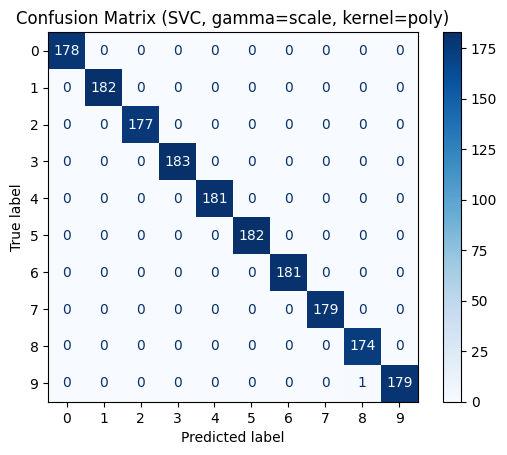

```python
# your code here
import matplotlib.pyplot as plt
from sklearn.metrics import ConfusionMatrixDisplay

best_gamma = "scale"
best_kernel = "poly"

final_model = SVC(gamma=best_gamma, kernel=best_kernel, random_state=42)
final_model.fit(X, y)
y_pred = final_model.predict(X)

print("Per-class metrics:\n")
print(classification_report(y, y_pred, zero_division=0))

cm_display = ConfusionMatrixDisplay.from_estimator(
    final_model, X, y, cmap="Blues", values_format="d"
)
plt.title(f"Confusion Matrix (SVC, gamma={best_gamma}, kernel={best_kernel})")
plt.show()
```

# Task 6: Make a table comparing results for average kfold and unseen results

```python
# your code here

table = [
    [ "Digit", "Avg Recall (kfold)","Avg Recall (unseen)", "Avg Precision (kfold)", "Avg Precision (unseen)"]
]
```

[output not shown]

Task 7: Rerun Full Workbook with the full data sample.

Once you have finished all of the tasks, go back and edit where you have these lines:

```
#short = ""
short = "short_"
```

and change them to:

```
short = ""
#short = "short_"
```

The choose the "Run All Cells" from the Run menu above. This will take about 10 minutes. While this is running you can start the assignmen_module3 workbook.

Make sure you "Save" the ipynb when this finishes! You can do this before doing the "Extra Challenges" below.

# Extra Challenge 1: Explore Hyperparameters Using Grid Search

sklearn has a method called GridSearchCV which allows a user to do a search over specified parameter values for an estimator. You give it an estimator (like SVC) and a list of paremeters to search over, and it handles all of the stpes to evaluate the estimator using cross validation. It returns scoring metrics for all of the aremneter combinations, as well as the overall best estimator.

Use this method to evaluate the following parameter setting:

- kernel: ['sigmoid','linear','rbf']
- C: [1,2,5,10] C is the Regularization parameter, and it controls the penalty for misclassification.
  - Higher C = higher penalty = less tolerance for misclassification.
  - Lower C = lower penalty = more tolerance for misclassification.

Print out the parameter combination of the best estimator as chosen by GridSearchCV.

NOTE: when calling GridSearchCV, make sure you include verbose=3 as a parameter to the call, so info is printed out while the method is running.

```python
#
# Your code here

from sklearn.model_selection import GridSearchCV
from sklearn.svm import SVC
```

```python
print()
print("Best estimator as chosen by GridSearchCV:",clf.best_params_)
```

[output not shown]

# Extra Challenge 2: Tabulate the Results of the Grid Search

Then **programmatically** make a "github" style table that looks like this:

| Parameters | Rank | Mean Score | STD Score |
| --- | --- | --- | --- |
| {'C': 1, 'kernel': 'sigmoid'} | xx | y.yyy | z.zzz |
| {'C': 1, 'kernel': 'linear'} | xx | y.yyy | z.zzz |
| {'C': 1, 'kernel': 'rbf'} | xx | y.yyy | z.zzz |
| {'C': 2, 'kernel': 'sigmoid'} | xx | y.yyy | z.zzz |
| {'C': 2, 'kernel': 'linear'} | xx | y.yyy | z.zzz |
| {'C': 2, 'kernel': 'rbf'} | xx | y.yyy | z.zzz |
| {'C': 5, 'kernel': 'sigmoid'} | xx | y.yyy | z.zzz |
| {'C': 5, 'kernel': 'linear'} | xx | y.yyy | z.zzz |
| {'C': 5, 'kernel': 'rbf'} | xx | y.yyy | z.zzz |
| {'C': 10, 'kernel': 'sigmoid'} | xx | y.yyy | z.zzz |
| {'C': 10, 'kernel': 'linear'} | xx | y.yyy | z.zzz |
| {'C': 10, 'kernel': 'rbf'} | xx | y.yyy | z.zzz |

# Extra Challenge 3:

Using the best parameters returned from GridSearchCV, rerun the training using these parameters, and evaluate the fit on the unseen data. Note that you can do this with just a few lines of code (we did this abiove in one of The tasks).

Print out the weighted average recall and precision on the unseen data

# Extra Challenge 3a: Compare above results to GridSearchCV

Compare your results on the unseen data to the best parameter results from GridSearchCV.

Before you can do this, you need to know: What is the "Mean Score" reported by GridSearchCV? Is it precision or recall?

YOUR RESPONSE: a) "Mean Score" reported by GridSearchCV corresponds to: (make sure you refer to the relevant documentation).

b) Unseen results compared to GridSearchCV

OFFICIAL ANSWER:

```python
print("total time for workbook",time.time()-t00)
```